# Using Data Analysis and Visualization to Explore Spotify's most listened-to songs and determine if the social media outlet "TikTok" had any influence

### Eric Gorner, Vivek Waghray, Ananya Nadig, Lily Etareri

## Motivation

#### The 4 of us are avid music listeners. We all have Spotify subscriptions and listen to music on a daily basis. We especially enjoy the "Spotify Wrapped" feature that comes out every year at the beginning of December.

#### This feature provides an easy to read, user friendly rundown of what you listened to over the past year. Among the information included is your most listened-to Artist, most listened-to songs, how much total time you spent listening to music on Spotify, and what genres you listened to. The end product is a Spotify-curated playlist of your top 100 or so songs that you listened to.

#### In the spirit of this feature, we wanted to take a look at the most listened to songs on Spotify as a whole, not just ourselves. We thought this would be very interesting and would be a cool way to get a sense of the music listened to on Spotify. However, in doing this, we wanted to incorporate a twist as well, this twist being the influence social media has on what music we listen to.

#### Over the past couple of years, one platform that rose in popularity was TikTok. This platform allows users to create and post short videos. These videos and their purposes range from comedy to even publicity, with many artists using the platform to promote their music. Something that we are curious about is the influence TikTok had on the music people listened to over the past 2 years. Did one year have more influence over the other?

## Resources

In the rest of the document below, you will see resources and techniques used for data analysis. If you are interested in learning about using Python in data analysis, please check out the resources below. These resources include very common libraries used in data analysis/visualization

https://pandas.pydata.org/

https://matplotlib.org/

Additionally, if you are intersted in finding data sets to use for analysis, follow the link below. This will provide you with numerous options to filter for data sets based off your intersts. I have also attached the link to my GitHub repository containing the CSV data set files used in this project.

https://www.kaggle.com/

https://github.com/egorner13/egorner13.github.io

## Data Collection and Cleaning

### Background on Data Sets

#### The data sets that we have selected to use are Data sets from the years 2021 and 2022. There is a data set for both years for TikTok data as well as Spotify data. The data sets that we have collected are from a collection that can be found on both Kaggle and Github. They are all constructed by the same author, so for the most part they are already very clean data sets with matching syntax (a song title that appears in one table will appear exactly the same in another table)

### Libraries

#### The below libraries are used in order to collect and analyze data. The pandas library is used to create dataframes of the data sets being used, and to then collect values for analysis. The matplotlib library is used to create plots, with sklearn used to create linear regression models

```python
%%capture --no-display
import pandas as pd
import numpy as np
from sklearn.linear_model import LinearRegression
import matplotlib.pyplot as plt
from sklearn import linear_model
import statsmodels.api as sm
```

### 2021 Datasets

#### Important Note: The main addition we made to the data sets was a rank variable that gave songs a rank. For Spotify, this number was based on the number of weeks they have spent on Spotify's top 200 chart. For TikTok, which does not release data regarding the number of times a person's sound/song is used in another person's video, this rank is based on the track popularity of the track used in the audio, as well as the artist's popularity behind the audio. This rank variable will provide us with a more accurate song ranking to better rank popular songs on both platforms.

```python
spotify_2021= pd.read_csv("spotify_top_charts_2021.csv", sep=',')
spotify_2021 = spotify_2021.drop(['uri'], axis=1)
rank = []

for i, row in spotify_2021.iterrows():
    rank.append(80*(row["weeks_on_chart"]/216) + 20*(row["peak_rank"]/82))

spotify_2021["rank"] = rank
spotify_2021 = spotify_2021.sort_values('rank', ascending = False)
spotify_2021 = spotify_2021.iloc[:-427 , :]
spotify_2021.reset_index(drop=True, inplace=True)
```

```python
spotify_2021
```

|  | artist_names | track_name | peak_rank | weeks_on_chart | danceability | energy | key | loudness | mode | speechiness | acousticness | instrumentalness | liveness | tempo | time_signature | duration_ms | rank |
| --- | --- | --- | --- | --- | --- | --- | --- | --- | --- | --- | --- | --- | --- | --- | --- | --- | --- |
| 0 | Imagine Dragons | Believer | 16 | 213 | 0.776 | 0.780 | 10 | -4.374 | 0 | 0.1280 | 0.062200 | 0.000000 | 0.0810 | 124.949 | 4 | 204347 | 82.791328 |
| 1 | James Arthur | Say You Won't Let Go | 7 | 216 | 0.358 | 0.557 | 10 | -7.398 | 1 | 0.0590 | 0.695000 | 0.000000 | 0.0902 | 85.043 | 4 | 211467 | 81.707317 |
| 2 | Ed Sheeran | Shape of You | 1 | 214 | 0.825 | 0.652 | 1 | -3.183 | 0 | 0.0802 | 0.581000 | 0.000000 | 0.0931 | 95.977 | 4 | 233713 | 79.503162 |
| 3 | Ed Sheeran | Perfect | 4 | 207 | 0.599 | 0.448 | 8 | -6.312 | 1 | 0.0232 | 0.163000 | 0.000000 | 0.1060 | 95.050 | 3 | 263400 | 77.642276 |
| 4 | Oasis | Wonderwall - Remastered | 152 | 98 | 0.405 | 0.894 | 2 | -4.336 | 1 | 0.0343 | 0.000801 | 0.000000 | 0.2260 | 174.502 | 4 | 259840 | 73.369467 |
| ... | ... | ... | ... | ... | ... | ... | ... | ... | ... | ... | ... | ... | ... | ... | ... | ... | ... |
| 595 | Ashnikko | Daisy | 45 | 19 | 0.834 | 0.663 | 8 | -6.143 | 1 | 0.1330 | 0.235000 | 0.000000 | 0.3720 | 121.876 | 4 | 146523 | 18.012647 |
| 596 | Jay Wheeler, DJ Nelson, Myke Towers | La Curiosidad | 19 | 36 | 0.845 | 0.677 | 11 | -4.798 | 0 | 0.1360 | 0.269000 | 0.000917 | 0.1080 | 90.013 | 4 | 219048 | 17.967480 |
| 597 | Lil Tecca | NEVER LEFT | 72 | 1 | 0.807 | 0.659 | 11 | -6.920 | 1 | 0.3320 | 0.022400 | 0.000000 | 0.3090 | 82.465 | 4 | 168727 | 17.931346 |
| 598 | Young Stoner Life, Young Thug, Gunna | Ski | 72 | 1 | 0.953 | 0.621 | 8 | -7.638 | 0 | 0.2210 | 0.017000 | 0.000000 | 0.0398 | 123.016 | 4 | 152333 | 17.931346 |
| 599 | Baby Keem, Travis Scott | durag activity (with Travis Scott) | 72 | 1 | 0.890 | 0.701 | 0 | -5.712 | 0 | 0.3420 | 0.003060 | 0.000003 | 0.0895 | 80.462 | 4 | 225020 | 17.931346 |

600 rows × 17 columns

```python
tiktok_2021 = pd.read_csv("TikTok_songs_2021.csv", sep=',')
rank = []

for i, row in tiktok_2021.iterrows():
    rank.append(90*(row["track_pop"]/91) + 10*(row["artist_pop"]/95))

tiktok_2021["rank"] = rank
tiktok_2021 = tiktok_2021.sort_values('rank', ascending = False)
tiktok_2021.reset_index(drop=True, inplace=True)
```

```python
tiktok_2021
```

|  | track_name | artist_name | artist_pop | album | track_pop | danceability | energy | loudness | mode | key | speechiness | acousticness | instrumentalness | liveness | valence | tempo | time_signature | duration_ms | rank |
| --- | --- | --- | --- | --- | --- | --- | --- | --- | --- | --- | --- | --- | --- | --- | --- | --- | --- | --- | --- |
| 0 | MIDDLE OF THE NIGHT | Elley Duhé | 75 | MIDDLE OF THE NIGHT | 91 | 0.410 | 0.611 | -8.271 | 0 | 4 | 0.0467 | 0.02280 | 0.000000 | 0.1160 | 0.0899 | 185.727 | 3 | 184448 | 97.894737 |
| 1 | Ghost | Justin Bieber | 90 | Justice | 89 | 0.601 | 0.741 | -5.569 | 1 | 2 | 0.0478 | 0.18500 | 0.000029 | 0.4150 | 0.4410 | 153.960 | 4 | 153190 | 97.495662 |
| 2 | Woman | Doja Cat | 88 | Planet Her | 89 | 0.824 | 0.764 | -4.175 | 0 | 5 | 0.0854 | 0.08880 | 0.002940 | 0.1170 | 0.8810 | 107.998 | 4 | 172627 | 97.285136 |
| 3 | Dandelions | Ruth B. | 75 | Safe Haven | 90 | 0.609 | 0.692 | -2.958 | 1 | 1 | 0.0259 | 0.01570 | 0.000000 | 0.0864 | 0.4540 | 116.959 | 3 | 233720 | 96.905726 |
| 4 | Save Your Tears | The Weeknd | 93 | After Hours | 88 | 0.680 | 0.826 | -5.487 | 1 | 0 | 0.0309 | 0.02120 | 0.000012 | 0.5430 | 0.6440 | 118.051 | 4 | 215627 | 96.822441 |
| ... | ... | ... | ... | ... | ... | ... | ... | ... | ... | ... | ... | ... | ... | ... | ... | ... | ... | ... | ... |
| 185 | SugarCrash! | ElyOtto | 57 | SugarCrash! | 1 | 0.745 | 0.740 | -6.558 | 1 | 0 | 0.0970 | 0.53000 | 0.000074 | 0.0936 | 0.3600 | 97.735 | 4 | 80118 | 6.989011 |
| 186 | YRN - Remix | Eduardo Luzquiños | 57 | YRN (Remix) | 0 | 0.808 | 0.782 | -8.505 | 0 | 7 | 0.1970 | 0.02410 | 0.001560 | 0.1230 | 0.6340 | 126.026 | 4 | 268355 | 6.000000 |
| 187 | Renai Circulation (English Cover) [2012 TV Size] | Lizz Robinett | 52 | Renai Circulation (English Cover) [TV Size] | 0 | 0.896 | 0.555 | -12.145 | 1 | 4 | 0.0850 | 0.25200 | 0.014300 | 0.1090 | 0.7720 | 120.013 | 4 | 91067 | 5.473684 |
| 188 | Savage Days | Eric D | 34 | Savage Days | 0 | 0.757 | 0.836 | -6.437 | 0 | 1 | 0.0601 | 0.00324 | 0.000663 | 0.0389 | 0.7560 | 136.883 | 4 | 138312 | 3.578947 |
| 189 | Fashion Week | cry | 0 | Fashion Week | 0 | 0.717 | 0.846 | -3.182 | 0 | 1 | 0.0329 | 0.00401 | 0.091300 | 0.0500 | 0.7130 | 136.961 | 4 | 155365 | 0.000000 |

190 rows × 19 columns

### 2022 Datasets

```python
spotify_2022 = pd.read_csv("spotify_top_charts_2022.csv", sep=',')
spotify_2022 = spotify_2022.drop(['uri'], axis=1)
rank = []

for i, row in spotify_2022.iterrows():
    rank.append(80*(row["weeks_on_chart"]/121) + 20*(row["peak_rank"]/30))

spotify_2022["rank"] = rank
spotify_2022 = spotify_2022.sort_values('rank', ascending = False)
spotify_2022 = spotify_2022.iloc[:-46 , :]
spotify_2022.reset_index(drop=True, inplace=True)
```

```python
spotify_2022
```

|  | artist_names | track_name | peak_rank | weeks_on_chart | danceability | energy | key | loudness | mode | speechiness | acousticness | instrumentalness | liveness | tempo | time_signature | duration_ms | rank |
| --- | --- | --- | --- | --- | --- | --- | --- | --- | --- | --- | --- | --- | --- | --- | --- | --- | --- |
| 0 | Imagine Dragons | Believer | 16 | 268 | 0.776 | 0.780 | 10 | -4.374 | 0 | 0.1280 | 0.0622 | 0.000000 | 0.0810 | 124.949 | 4 | 204347 | 187.856749 |
| 1 | James Arthur | Say You Won't Let Go | 7 | 268 | 0.358 | 0.557 | 10 | -7.398 | 1 | 0.0590 | 0.6950 | 0.000000 | 0.0902 | 85.043 | 4 | 211467 | 181.856749 |
| 2 | Ed Sheeran | Shape of You | 1 | 269 | 0.825 | 0.652 | 1 | -3.183 | 0 | 0.0802 | 0.5810 | 0.000000 | 0.0931 | 95.977 | 4 | 233713 | 178.517906 |
| 3 | Ed Sheeran | Perfect | 4 | 262 | 0.599 | 0.448 | 8 | -6.312 | 1 | 0.0232 | 0.1630 | 0.000000 | 0.1060 | 95.050 | 3 | 263400 | 175.889807 |
| 4 | John Legend | All of Me | 110 | 145 | 0.422 | 0.264 | 8 | -7.064 | 1 | 0.0322 | 0.9220 | 0.000000 | 0.1320 | 119.930 | 4 | 269560 | 169.201102 |
| ... | ... | ... | ... | ... | ... | ... | ... | ... | ... | ... | ... | ... | ... | ... | ... | ... | ... |
| 595 | Bad Bunny, Rauw Alejandro | Party | 6 | 14 | 0.829 | 0.799 | 9 | -5.389 | 1 | 0.0897 | 0.0151 | 0.000543 | 0.2420 | 97.013 | 4 | 227629 | 13.256198 |
| 596 | Jack Harlow | First Class | 2 | 18 | 0.902 | 0.582 | 5 | -5.902 | 0 | 0.1090 | 0.1110 | 0.000003 | 0.1110 | 107.005 | 4 | 173948 | 13.234160 |
| 597 | Harry Styles | As It Was | 1 | 19 | 0.520 | 0.731 | 6 | -5.338 | 0 | 0.0557 | 0.3420 | 0.001010 | 0.3110 | 173.930 | 4 | 167303 | 13.228650 |
| 598 | GAYLE | abcdefu | 1 | 19 | 0.695 | 0.540 | 4 | -5.692 | 1 | 0.0493 | 0.2990 | 0.000000 | 0.3670 | 121.932 | 4 | 168602 | 13.228650 |
| 599 | Taylor Swift | All Too Well (10 Minute Version) (Taylor's Ver... | 1 | 19 | 0.631 | 0.518 | 0 | -8.771 | 1 | 0.0303 | 0.2740 | 0.000000 | 0.0880 | 93.023 | 4 | 613027 | 13.228650 |

600 rows × 17 columns

```python
tiktok_2022 = pd.read_csv("TikTok_songs_2022.csv", sep=',')
rank = []

for i, row in tiktok_2022.iterrows():
    rank.append(90*(row["track_pop"]/97) + 10*(row["artist_pop"]/95))

tiktok_2022["rank"] = rank
tiktok_2022 = tiktok_2022.sort_values('rank', ascending = False)
tiktok_2022.reset_index(drop=True, inplace=True)
```

```python
tiktok_2022
```

|  | track_name | artist_name | artist_pop | album | track_pop | danceability | energy | loudness | mode | key | speechiness | acousticness | instrumentalness | liveness | valence | tempo | time_signature | duration_ms | rank |
| --- | --- | --- | --- | --- | --- | --- | --- | --- | --- | --- | --- | --- | --- | --- | --- | --- | --- | --- | --- |
| 0 | Glimpse of Us | Joji | 85 | Glimpse of Us | 97 | 0.440 | 0.317 | -9.258 | 1 | 8 | 0.0531 | 0.891000 | 0.000005 | 0.1410 | 0.2680 | 169.914 | 3 | 233456 | 98.947368 |
| 1 | As It Was | Harry Styles | 91 | As It Was | 96 | 0.520 | 0.731 | -5.338 | 0 | 6 | 0.0557 | 0.342000 | 0.001010 | 0.3110 | 0.6620 | 173.930 | 4 | 167303 | 98.651112 |
| 2 | Running Up That Hill (A Deal With God) | Kate Bush | 81 | Hounds Of Love | 95 | 0.629 | 0.547 | -13.123 | 0 | 10 | 0.0550 | 0.720000 | 0.003140 | 0.0604 | 0.1970 | 108.375 | 4 | 298933 | 96.670646 |
| 3 | Late Night Talking | Harry Styles | 91 | Harry's House | 93 | 0.714 | 0.728 | -4.595 | 1 | 10 | 0.0468 | 0.298000 | 0.000000 | 0.1060 | 0.9010 | 114.996 | 4 | 177955 | 95.867607 |
| 4 | Jimmy Cooks (feat. 21 Savage) | Drake | 95 | Honestly, Nevermind | 92 | 0.529 | 0.673 | -4.711 | 1 | 0 | 0.1750 | 0.000307 | 0.000002 | 0.0930 | 0.3660 | 165.921 | 4 | 218365 | 95.360825 |
| ... | ... | ... | ... | ... | ... | ... | ... | ... | ... | ... | ... | ... | ... | ... | ... | ... | ... | ... | ... |
| 258 | Right Here Waiting | Boostereo | 52 | Right Here Waiting | 0 | 0.639 | 0.704 | -7.332 | 1 | 10 | 0.0352 | 0.064600 | 0.000000 | 0.4450 | 0.2850 | 115.052 | 4 | 180522 | 5.473684 |
| 259 | Looking for Love | Asketa & Natan Chaim | 42 | Looking for Love | 0 | 0.748 | 0.894 | -4.677 | 1 | 7 | 0.0998 | 0.311000 | 0.000029 | 0.2390 | 0.5030 | 120.004 | 4 | 148000 | 4.421053 |
| 260 | AMG | Jt5k | 36 | AMG | 0 | 0.802 | 0.509 | -6.889 | 0 | 10 | 0.1810 | 0.028300 | 0.000000 | 0.3070 | 0.0567 | 87.849 | 4 | 135000 | 3.789474 |
| 261 | What If | HOURS | 35 | What If | 0 | 0.609 | 0.777 | -5.879 | 1 | 6 | 0.0353 | 0.001620 | 0.000001 | 0.0730 | 0.3490 | 126.001 | 4 | 154286 | 3.684211 |
| 262 | Fever - Remix | XY&O | 31 | Fever (Remix) | 0 | 0.782 | 0.586 | -6.067 | 0 | 10 | 0.0567 | 0.060800 | 0.004090 | 0.1150 | 0.7240 | 120.018 | 4 | 156000 | 3.263158 |

263 rows × 19 columns

## 2021 Data Visualization, Analysis, and Comparisons

### 2021 Spotify Data Visualization and Analysis

#### Which artists were most popular in 2021?

```python
# top 10 artists of 2021 (displayed by which artists had the highest ranks)
print("The artists that had the top 10 songs in 2021 were: ")
count = 0
artists = []
for i, row in spotify_2021.iterrows():
    if row["artist_names"] not in artists:
        artists.append(row["artist_names"])
    if len(artists) == 10:
        break
    # Alternate code to avoid having multiple artists
    # temp_name = str(row["artist_names"])
    # artist_name = temp_name.split(', ')
    # for j in artist_name:
    #     if j not in artists:
    #         artists.append(j)
    #     if len(artists) == 10:
    #         break
    # if len(artists) == 10:
    #         break
for i in artists:
    print(i)
```

```
The artists that had the top 10 songs in 2021 were:
Imagine Dragons
James Arthur
Ed Sheeran
Oasis
Travis Scott
XXXTENTACION
John Legend
Post Malone, 21 Savage
Billie Eilish, Khalid
The Chainsmokers, Coldplay
```

```python
# top 10 artists of 2021 (in terms of which artists appeared the most frequently in the top 600
artists_df = pd.DataFrame(spotify_2021['artist_names'].value_counts())
artists_df.rename({'artist_names': 'Number of Times Appeared in Top 600'}, axis=1, inplace=True)
artists_df
print(artists_df.iloc[:10])
```

```
                                        Number of Times Appeared in Top 600
Taylor Swift                                                             22
Ed Sheeran                                                               10
Juice WRLD                                                                9
Billie Eilish                                                             9
Kanye West                                                                8
Morgan Wallen                                                             6
XXXTENTACION                                                              5
The Weeknd                                                                5
Adele                                                                     5
Bruno Mars, Anderson .Paak, Silk Sonic                                    4
```

#### Analysis of Song Characteristics for 2021

Let's analyze different song characteristics and see if there is any correlation between these features and the songs' ranks

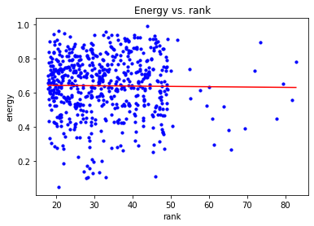

```python
X = spotify_2021['rank'].values.reshape(-1, 1)
Y = spotify_2021['energy'].values.reshape(-1, 1)
linear_regressor = LinearRegression()
linear_regressor.fit(X, Y)
Y_pred = linear_regressor.predict(X)

plt.scatter(X, Y, s = 10, color = "blue")
plt.plot(X, Y_pred, color='red')
plt.title("Energy vs. rank")
plt.ylabel("energy")
plt.xlabel("rank")
plt.show()
```

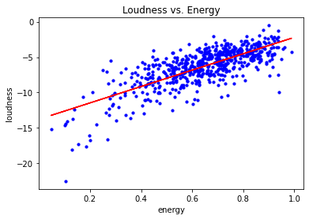

```python
# energy and loudness have a positive correlation
X = spotify_2021['energy'].values.reshape(-1, 1)
Y = spotify_2021['loudness'].values.reshape(-1, 1)
linear_regressor = LinearRegression()
linear_regressor.fit(X, Y)
Y_pred = linear_regressor.predict(X)

plt.scatter(X, Y, s = 10, color = "blue")
plt.plot(X, Y_pred, color='red')
plt.title("Loudness vs. Energy")
plt.xlabel("energy")
plt.ylabel("loudness")
plt.show()
```

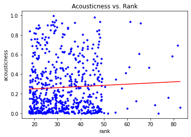

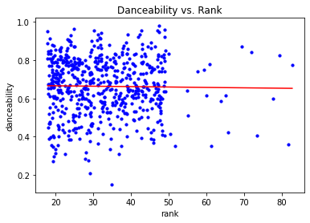

```python
# Not much correlation between rank and other song characterists, acousticness vs. rank has a slight positive correlation
X = spotify_2021['rank'].values.reshape(-1, 1)
Y = spotify_2021['acousticness'].values.reshape(-1, 1)
linear_regressor = LinearRegression()
linear_regressor.fit(X, Y)
Y_pred = linear_regressor.predict(X)

plt.scatter(X, Y, s = 10, color = "blue")
plt.plot(X, Y_pred, color='red')
plt.title("Acousticness vs. Rank")
plt.xlabel("rank")
plt.ylabel("acousticness")
plt.show()

X = spotify_2021['rank'].values.reshape(-1, 1)
Y = spotify_2021['danceability'].values.reshape(-1, 1)
linear_regressor = LinearRegression()
linear_regressor.fit(X, Y)
Y_pred = linear_regressor.predict(X)

plt.scatter(X, Y, s = 10, color = "blue")
plt.plot(X, Y_pred, color='red')
plt.title("Danceability vs. Rank")
plt.xlabel("rank")
plt.ylabel("danceability")
plt.show()
```

```python
weekly = spotify_2021
weekly = weekly.sort_values('weeks_on_chart', ascending = False)
weekly = weekly.iloc[:- 590, :]
weekly = weekly.drop(['artist_names', 'peak_rank', 'danceability', 'energy', 'key', 'loudness', 'mode', 'speechiness', 'acousticness', 'instrumentalness', 'liveness', 'tempo', 'time_signature', 'duration_ms', 'rank'], axis=1)
weekly.rename({'weeks_on_chart': 'Top 10 Songs with the Most Weekly Appearances'}, axis=1, inplace=True)

weekly
```

|  | track_name | Top 10 Songs with the Most Weekly Appearances |
| --- | --- | --- |
| 1 | Say You Won't Let Go | 216 |
| 2 | Shape of You | 214 |
| 0 | Believer | 213 |
| 3 | Perfect | 207 |
| 5 | goosebumps | 186 |
| 6 | Jocelyn Flores | 183 |
| 9 | rockstar (feat. 21 Savage) | 172 |
| 12 | Something Just Like This | 161 |
| 13 | Closer | 159 |
| 14 | SAD! | 155 |

### 2021 Tiktok Data Analysis

#### Which artists were most popular on Tiktok in 2021

##### This is based on their rank which was calculated by combining the popularity of the track and the popularity of the artists. We decided that the popularity of tracks were more important than the popularity of the artist so track popularity had more weight than artist popularity when deciding the rank of each song.

```python
print("The top 10 artists on Tiktok for 2021 are: ")
top_artists = []
for i, row in tiktok_2021.iterrows():
    if row["artist_name"] not in top_artists:
        top_artists.append(row["artist_name"])
        print(row["artist_name"])
    if len(top_artists) == 10:
        break
```

```
The top 10 artists on Tiktok for 2021 are:
Elley Duhé
Justin Bieber
Doja Cat
Ruth B.
The Weeknd
The Kid LAROI
Olivia Rodrigo
Lil Nas X
Farruko
GAYLE
```

```python
# top 10 artists of 2021 (in terms of which artists appeared the most frequently in the top 600
artists_df = pd.DataFrame(tiktok_2021['artist_name'].value_counts())
artists_df.rename({'artist_name': 'Number of Times Appeared in Top 200'}, axis=1, inplace=True)
artists_df
print(artists_df.iloc[:10])
```

```
                Number of Times Appeared in Top 200
Justin Bieber                                     7
Doja Cat                                          5
Olivia Rodrigo                                    4
Ariana Grande                                     3
Lil Nas X                                         3
Katy Perry                                        3
blackbear                                         3
Iyaz                                              2
BTS                                               2
Bazzi                                             2
```

##### Although we used different metrics to calculate the rank of each tiktok song, we can see that there are similarities between the artists behind the top ranked songs and the number of songs those artists created that appeared in the top 200. The top 10 artists based on rank that also were top 10 based on the frequency of their appearance in the top 200 list are Justin Beiber, Doja Cat, Olivia Rodrigo, and Lil Nas X

#### Visual representation of the song characteristics

##### Let's compare song characteristics and see if or how different features correlate with song rank

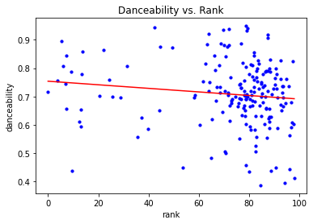

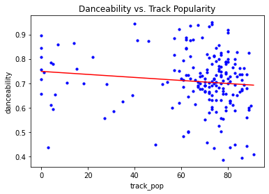

```python
X = tiktok_2021['rank'].values.reshape(-1, 1)
Y = tiktok_2021['danceability'].values.reshape(-1, 1)
linear_regressor = LinearRegression()
linear_regressor.fit(X, Y)
Y_pred = linear_regressor.predict(X)

plt.scatter(X, Y, s = 10, color = "blue")
plt.plot(X, Y_pred, color='red')
plt.title("Danceability vs. Rank")
plt.xlabel("rank")
plt.ylabel("danceability")
plt.show()

X = tiktok_2021['track_pop'].values.reshape(-1, 1)
Y = tiktok_2021['danceability'].values.reshape(-1, 1)
linear_regressor = LinearRegression()
linear_regressor.fit(X, Y)
Y_pred = linear_regressor.predict(X)

plt.scatter(X, Y, s = 10, color = "blue")
plt.plot(X, Y_pred, color='red')
plt.title("Danceability vs. Track Popularity")
plt.xlabel("track_pop")
plt.ylabel("danceability")
plt.show()
```

##### There seems to be a negative correlation between danceability and rank which is a lot different from what we would assume. Dancing tiktoks are some of the most popular types of videos on the platform so it's interesting that songs with a higher danceability score aren't really more likely to be ranked higher in terms of our ranking system or even in terms of track popularity alone

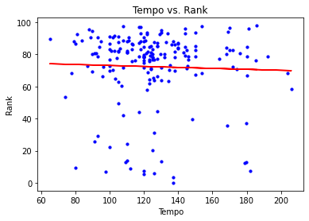

```python
X = tiktok_2021['tempo'].values.reshape(-1, 1)
Y = tiktok_2021['rank'].values.reshape(-1, 1)
linear_regressor = LinearRegression()
linear_regressor.fit(X, Y)
Y_pred = linear_regressor.predict(X)

plt.scatter(X, Y, s = 10, color = "blue")
plt.plot(X, Y_pred, color='red')
plt.title("Tempo vs. Rank")
plt.xlabel("Tempo")
plt.ylabel("Rank")
plt.show()
```

##### The points seems to cluster around tempos between 100 bpm and 150bpm for highly ranked songs. Overall, the line of regression shows there is a slightly negative correlation between tempo and rank meaning that faster songs are more likely to be ranked lower.

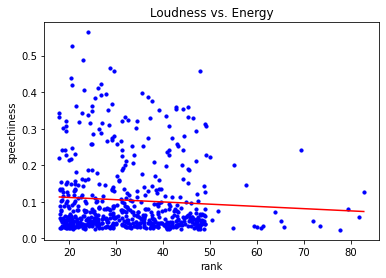

```python
X = spotify_2021['rank'].values.reshape(-1, 1)
Y = spotify_2021['speechiness'].values.reshape(-1, 1)
linear_regressor = LinearRegression()
linear_regressor.fit(X, Y)
Y_pred = linear_regressor.predict(X)

plt.scatter(X, Y, s = 10, color = "blue")
plt.plot(X, Y_pred, color='red')
plt.title("Loudness vs. Energy")
plt.xlabel("rank")
plt.ylabel("speechiness")
plt.show()
```

#### Is there a correlation between artist and track popularity?

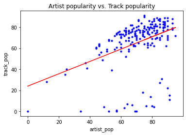

```python
X = tiktok_2021['artist_pop'].values.reshape(-1, 1)
Y = tiktok_2021['track_pop'].values.reshape(-1, 1)
linear_regressor = LinearRegression()
linear_regressor.fit(X, Y)
Y_pred = linear_regressor.predict(X)

plt.scatter(X, Y, s = 10, color = "blue")
plt.plot(X, Y_pred, color='red')
plt.title("Artist popularity vs. Track popularity")
plt.ylabel("track_pop")
plt.xlabel("artist_pop")
plt.show()
```

##### There is a strong correlation between artist popularity and track popularity. The more popular an artist is on tiktok, the higher the popularity of their tracks. We can see though, that there are outliers, and some artists with higher popularity have tracks that don't perform as well.

### Comparison of Tik Tok vs. Spotify Data

```python
temp_spotify_2021 = spotify_2021
temp_spotify_2021 = temp_spotify_2021.drop(['peak_rank', 'weeks_on_chart', 'danceability', 'energy', 'key', 'loudness', 'mode', 'speechiness', 'acousticness', 'instrumentalness', 'liveness', 'tempo', 'time_signature', 'duration_ms'], axis=1)
temp_spotify_2021 = temp_spotify_2021.iloc[:-500 , :]
temp_spotify_2021.rename({'artist_names': 'artist_name'}, axis=1, inplace=True)
temp_spotify_2021
```

|  | artist_name | track_name | rank |
| --- | --- | --- | --- |
| 0 | Imagine Dragons | Believer | 82.791328 |
| 1 | James Arthur | Say You Won't Let Go | 81.707317 |
| 2 | Ed Sheeran | Shape of You | 79.503162 |
| 3 | Ed Sheeran | Perfect | 77.642276 |
| 4 | Oasis | Wonderwall - Remastered | 73.369467 |
| ... | ... | ... | ... |
| 95 | MEDUZA, Hozier | Tell It To My Heart | 44.272809 |
| 96 | Selena Gomez, Camilo | 999 (with Camilo) | 44.272809 |
| 97 | Doja Cat | Been Like This | 44.028907 |
| 98 | Polo G, Pop Smoke, Fivio Foreign | Clueless (with Pop Smoke & Fivio Foreign) | 44.028907 |
| 99 | Ruth B. | Dandelions | 43.911472 |

100 rows × 3 columns

```python
temp_tiktok_2021 = tiktok_2021
temp_tiktok_2021 = temp_tiktok_2021.drop(['artist_pop','album', 'track_pop','danceability','energy','loudness','mode','key','speechiness', 'acousticness', 'instrumentalness', 'liveness', 'valence', 'tempo', 'time_signature','duration_ms'], axis=1)
temp_tiktok_2021
```

|  | track_name | artist_name | rank |
| --- | --- | --- | --- |
| 0 | MIDDLE OF THE NIGHT | Elley Duhé | 97.894737 |
| 1 | Ghost | Justin Bieber | 97.495662 |
| 2 | Woman | Doja Cat | 97.285136 |
| 3 | Dandelions | Ruth B. | 96.905726 |
| 4 | Save Your Tears | The Weeknd | 96.822441 |
| ... | ... | ... | ... |
| 185 | SugarCrash! | ElyOtto | 6.989011 |
| 186 | YRN - Remix | Eduardo Luzquiños | 6.000000 |
| 187 | Renai Circulation (English Cover) [2012 TV Size] | Lizz Robinett | 5.473684 |
| 188 | Savage Days | Eric D | 3.578947 |
| 189 | Fashion Week | cry | 0.000000 |

190 rows × 3 columns

```python
# Overlap with top 600 spotify songs
temp_spotify_2021 = spotify_2021
temp_spotify_2021 = temp_spotify_2021.drop(['peak_rank', 'weeks_on_chart', 'danceability', 'energy', 'key', 'loudness', 'mode', 'speechiness', 'acousticness', 'instrumentalness', 'liveness', 'tempo', 'time_signature', 'duration_ms', 'rank'], axis=1)
temp_spotify_2021.rename({'artist_names': 'artist_name'}, axis=1, inplace=True)
temp_spotify_2021
all_2021_top100 = pd.merge(temp_spotify_2021, temp_tiktok_2021, how='inner', on=['track_name'])
all_2021_top100
```

|  | artist_name_x | track_name | artist_name_y | rank |
| --- | --- | --- | --- | --- |
| 0 | Pamungkas | To the Bone | Pamungkas | 84.195489 |
| 1 | Elley Duhé | MIDDLE OF THE NIGHT | Elley Duhé | 97.894737 |
| 2 | Sub Urban, Bella Poarch | INFERNO | Sub Urban | 77.272412 |
| 3 | Ruth B. | Dandelions | Ruth B. | 96.905726 |
| 4 | Shouse, David Guetta | Love Tonight - David Guetta Remix Edit | Shouse | 87.583574 |
| 5 | Taylor Swift | Wildest Dreams | Taylor Swift | 86.932331 |
| 6 | JIN | Yours | Raiden | 72.726431 |
| 7 | Amaarae, Kali Uchis, Moliy | SAD GIRLZ LUV MONEY Remix (feat. Kali Uchis an... | Amaarae | 13.659919 |
| 8 | Gym Class Heroes, Adam Levine | Stereo Hearts (feat. Adam Levine) | Gym Class Heroes | 69.465587 |
| 9 | Conan Gray | Maniac | Conan Gray | 88.636206 |
| 10 | Jaymes Young | Infinity | Jaymes Young | 92.528629 |
| 11 | MKTO | Classic | MKTO | 70.244072 |
| 12 | blackbear | hot girl bummer | blackbear | 13.366108 |
| 13 | Jamie Miller | Here's Your Perfect | Jamie Miller | 82.995951 |
| 14 | Sean Paul, Dua Lipa | No Lie | Sean Paul | 90.403702 |
| 15 | Pink Sweat$ | At My Worst | Pink Sweat$ | 80.449971 |
| 16 | BØRNS | Electric Love | BØRNS | 88.151533 |
| 17 | Madison Beer | Reckless | Madison Beer | 84.616541 |
| 18 | Doja Cat | Say So | Doja Cat | 88.384037 |
| 19 | bbno$, Rich Brian | edamame (feat. Rich Brian) | bbno$ | 83.732794 |
| 20 | RealestK | WFM | RealestK | 9.493349 |
| 21 | Dua Lipa | Levitating | Dua Lipa | 91.351070 |
| 22 | Jason Derulo | Take You Dancing | Jason Derulo | 86.552921 |
| 23 | dhruv | double take | dhruv | 12.986698 |

```python
# Overlap based on top 100 spotify songs
all_2021_top100 = pd.merge(temp_spotify_2021, temp_tiktok_2021, how='inner', on=['track_name'])
all_2021_top100
```

|  | artist_name_x | track_name | artist_name_y | rank |
| --- | --- | --- | --- | --- |
| 0 | Pamungkas | To the Bone | Pamungkas | 84.195489 |
| 1 | Elley Duhé | MIDDLE OF THE NIGHT | Elley Duhé | 97.894737 |
| 2 | Sub Urban, Bella Poarch | INFERNO | Sub Urban | 77.272412 |
| 3 | Ruth B. | Dandelions | Ruth B. | 96.905726 |
| 4 | Shouse, David Guetta | Love Tonight - David Guetta Remix Edit | Shouse | 87.583574 |
| 5 | Taylor Swift | Wildest Dreams | Taylor Swift | 86.932331 |
| 6 | JIN | Yours | Raiden | 72.726431 |
| 7 | Amaarae, Kali Uchis, Moliy | SAD GIRLZ LUV MONEY Remix (feat. Kali Uchis an... | Amaarae | 13.659919 |
| 8 | Gym Class Heroes, Adam Levine | Stereo Hearts (feat. Adam Levine) | Gym Class Heroes | 69.465587 |
| 9 | Conan Gray | Maniac | Conan Gray | 88.636206 |
| 10 | Jaymes Young | Infinity | Jaymes Young | 92.528629 |
| 11 | MKTO | Classic | MKTO | 70.244072 |
| 12 | blackbear | hot girl bummer | blackbear | 13.366108 |
| 13 | Jamie Miller | Here's Your Perfect | Jamie Miller | 82.995951 |
| 14 | Sean Paul, Dua Lipa | No Lie | Sean Paul | 90.403702 |
| 15 | Pink Sweat$ | At My Worst | Pink Sweat$ | 80.449971 |
| 16 | BØRNS | Electric Love | BØRNS | 88.151533 |
| 17 | Madison Beer | Reckless | Madison Beer | 84.616541 |
| 18 | Doja Cat | Say So | Doja Cat | 88.384037 |
| 19 | bbno$, Rich Brian | edamame (feat. Rich Brian) | bbno$ | 83.732794 |
| 20 | RealestK | WFM | RealestK | 9.493349 |
| 21 | Dua Lipa | Levitating | Dua Lipa | 91.351070 |
| 22 | Jason Derulo | Take You Dancing | Jason Derulo | 86.552921 |
| 23 | dhruv | double take | dhruv | 12.986698 |

## 2022 Data Visualization, Analysis, and Comparisons

### 2022 Spotify Data Visualization and Analysis

```python
# top 10 artists of 2022 (displayed by which artists had the highest ranks)
print("The artists that had the top 10 songs in 2022 were: ")
count = 0
artists = []
for i, row in spotify_2022.iterrows():
    if row["artist_names"] not in artists:
        artists.append(row["artist_names"])
    if len(artists) == 10:
        break
    # Alternate code to avoid having multiple artists
    # temp_name = str(row["artist_names"])
    # artist_name = temp_name.split(', ')
    # for j in artist_name:
    #     if j not in artists:
    #         artists.append(j)
    #     if len(artists) == 10:
    #         break
    # if len(artists) == 10:
    #         break
for i in artists:
    print(i)
```

```
The artists that had the top 10 songs in 2022 were:
Imagine Dragons
James Arthur
Ed Sheeran
John Legend
Travis Scott
Billie Eilish, Khalid
XXXTENTACION
Miksu / Macloud, t-low
Kanye West
Fivio Foreign, The Kid LAROI
```

```python
# top 10 artists of 2022 (in terms of which artists appeared the most frequently in the top 600
artists_df = pd.DataFrame(spotify_2022['artist_names'].value_counts())
artists_df.rename({'artist_names': 'Number of Times Appeared in Top 600'}, axis=1, inplace=True)
artists_df
print(artists_df.iloc[:10])
```

```
                Number of Times Appeared in Top 600
Bad Bunny                                        17
The Weeknd                                       15
Beyoncé                                          14
Drake                                            12
Kendrick Lamar                                   10
Harry Styles                                      8
Post Malone                                       7
Olivia Rodrigo                                    7
Future                                            7
Taylor Swift                                      7
```

#### Analysis of Song Characteristics for 2022

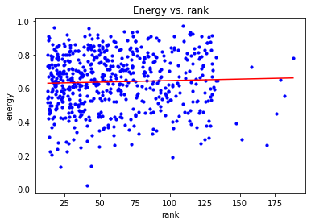

```python
X = spotify_2022['rank'].values.reshape(-1, 1)
Y = spotify_2022['energy'].values.reshape(-1, 1)
linear_regressor = LinearRegression()
linear_regressor.fit(X, Y)
Y_pred = linear_regressor.predict(X)

plt.scatter(X, Y, s = 10, color = "blue")
plt.plot(X, Y_pred, color='red')
plt.title("Energy vs. rank")
plt.ylabel("energy")
plt.xlabel("rank")
plt.show()
```

##### Similarly to 2021, there doesn't seem to be a correlation between energy and rank.

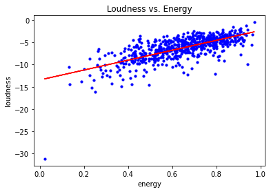

```python
# Energy and loudness maintain a strong positive correlation
X = spotify_2022['energy'].values.reshape(-1, 1)
Y = spotify_2022['loudness'].values.reshape(-1, 1)
linear_regressor = LinearRegression()
linear_regressor.fit(X, Y)
Y_pred = linear_regressor.predict(X)

plt.scatter(X, Y, s = 10, color = "blue")
plt.plot(X, Y_pred, color='red')
plt.title("Loudness vs. Energy")
plt.xlabel("energy")
plt.ylabel("loudness")
plt.show()
```

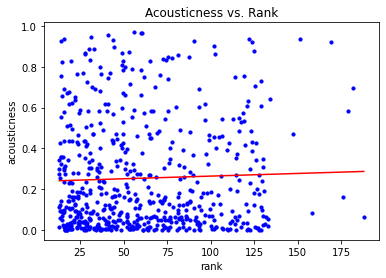

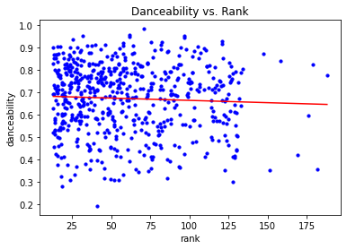

```python
# Not much correlation between rank and other song characterists, or acousticness and rank
X = spotify_2022['rank'].values.reshape(-1, 1)
Y = spotify_2022['acousticness'].values.reshape(-1, 1)
linear_regressor = LinearRegression()
linear_regressor.fit(X, Y)
Y_pred = linear_regressor.predict(X)

plt.scatter(X, Y, s = 10, color = "blue")
plt.plot(X, Y_pred, color='red')
plt.title("Acousticness vs. Rank")
plt.xlabel("rank")
plt.ylabel("acousticness")
plt.show()

X = spotify_2022['rank'].values.reshape(-1, 1)
Y = spotify_2022['danceability'].values.reshape(-1, 1)
linear_regressor = LinearRegression()
linear_regressor.fit(X, Y)
Y_pred = linear_regressor.predict(X)

plt.scatter(X, Y, s = 10, color = "blue")
plt.plot(X, Y_pred, color='red')
plt.title("Danceability vs. Rank")
plt.xlabel("rank")
plt.ylabel("danceability")
plt.show()
```

```python
weekly = spotify_2022
weekly = weekly.sort_values('weeks_on_chart', ascending = False)
weekly = weekly.iloc[:- 590, :]
weekly = weekly.drop(['artist_names', 'peak_rank', 'danceability', 'energy', 'key', 'loudness', 'mode', 'speechiness', 'acousticness', 'instrumentalness', 'liveness', 'tempo', 'time_signature', 'duration_ms', 'rank'], axis=1)
weekly.rename({'weeks_on_chart': 'Top 10 Songs with the Most Weekly Appearances'}, axis=1, inplace=True)

weekly
```

|  | track_name | Top 10 Songs with the Most Weekly Appearances |
| --- | --- | --- |
| 2 | Shape of You | 269 |
| 0 | Believer | 268 |
| 1 | Say You Won't Let Go | 268 |
| 3 | Perfect | 262 |
| 5 | goosebumps | 226 |
| 7 | Jocelyn Flores | 216 |
| 6 | lovely (with Khalid) | 205 |
| 14 | Lucid Dreams | 194 |
| 26 | Bohemian Rhapsody - Remastered 2011 | 182 |
| 54 | Sunflower - Spider-Man: Into the Spider-Verse | 179 |

### 2022 TikTok Data Visualization and Analysis

#### Which artists were most popular on Tiktok in 2022

```python
# top 10 artists of 2022 (displayed by which artists had the highest ranking songs)
print("The artists with the 10 most popular songs on TikTok in 2022 were: ")
count = 0
artists = []
for i, row in tiktok_2022.iterrows():
    if row["artist_name"] not in artists:
        artists.append(row["artist_name"])
    if len(artists) == 10:
        break
for i in artists:
    print(i)
```

```
The artists with the 10 most popular songs on TikTok in 2022 were:
Joji
Harry Styles
Kate Bush
Drake
Lizzo
The Weeknd
Elley Duhé
The Neighbourhood
Doja Cat
Jack Harlow
```

```python
# top 10 artists of 2022 (in terms of which artists appeared the most frequently in the top 600
artists_df = pd.DataFrame(tiktok_2022['artist_name'].value_counts())
artists_df.rename({'artist_name': 'Number of Times Appeared in Top 600'}, axis=1, inplace=True)
artists_df
print(artists_df.iloc[:10])
```

```
                Number of Times Appeared in Top 600
Doja Cat                                          8
Coopex                                            6
Dame Dame                                         5
Alex Alexander                                    4
Farux                                             4
YES YES                                           4
Lil Nas X                                         4
The Kid LAROI                                     3
Nito-Onna                                         3
Alex D'Rosso                                      3
```

##### Conversely to 2022, the relationship between having the highest ranking song and having the most appearances on the top 600 is not as strong. In this case, only Doja Cat appears on both lists.

#### Visual representation of the song characteristics

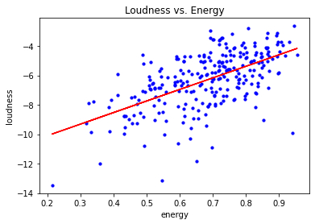

```python
# energy and loudness have a strong positive correlation
X = tiktok_2022['energy'].values.reshape(-1, 1)
Y = tiktok_2022['loudness'].values.reshape(-1, 1)
linear_regressor = LinearRegression()
linear_regressor.fit(X, Y)
Y_pred = linear_regressor.predict(X)

plt.scatter(X, Y, s = 10, color = "blue")
plt.plot(X, Y_pred, color='red')
plt.title("Loudness vs. Energy")
plt.xlabel("energy")
plt.ylabel("loudness")
plt.show()
```

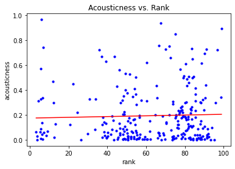

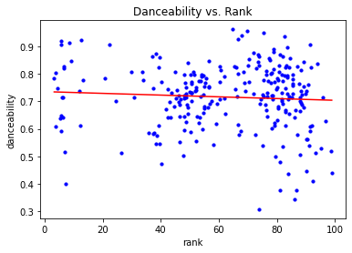

```python
# Not much correlation between rank and other song characterists, or acousticness and rank
X = tiktok_2022['rank'].values.reshape(-1, 1)
Y = tiktok_2022['acousticness'].values.reshape(-1, 1)
linear_regressor = LinearRegression()
linear_regressor.fit(X, Y)
Y_pred = linear_regressor.predict(X)

plt.scatter(X, Y, s = 10, color = "blue")
plt.plot(X, Y_pred, color='red')
plt.title("Acousticness vs. Rank")
plt.xlabel("rank")
plt.ylabel("acousticness")
plt.show()

X = tiktok_2022['rank'].values.reshape(-1, 1)
Y = tiktok_2022['danceability'].values.reshape(-1, 1)
linear_regressor = LinearRegression()
linear_regressor.fit(X, Y)
Y_pred = linear_regressor.predict(X)

plt.scatter(X, Y, s = 10, color = "blue")
plt.plot(X, Y_pred, color='red')
plt.title("Danceability vs. Rank")
plt.xlabel("rank")
plt.ylabel("danceability")
plt.show()
```

##### There seems to be a continued negative correlation between danceability and rank, which again is quite surprising for a platform with a lot of it's content revolving around dancing.

### Is there a correlation between artist and track popularity for 2022?

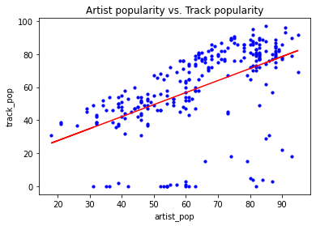

```python
X = tiktok_2022['artist_pop'].values.reshape(-1, 1)
Y = tiktok_2022['track_pop'].values.reshape(-1, 1)
linear_regressor = LinearRegression()
linear_regressor.fit(X, Y)
Y_pred = linear_regressor.predict(X)

plt.scatter(X, Y, s = 10, color = "blue")
plt.plot(X, Y_pred, color='red')
plt.title("Artist popularity vs. Track popularity")
plt.ylabel("track_pop")
plt.xlabel("artist_pop")
plt.show()
```

##### There is a strong correlation between artist popularity and track popularity, with the data being more spread around the regression line as opposed to clustering.

### Comparison of Tik Tok vs. Spotify Data

#### Let us again look at the most commonly appearing names on both the Spotify and TikTok charts, this time in the form of bar charts

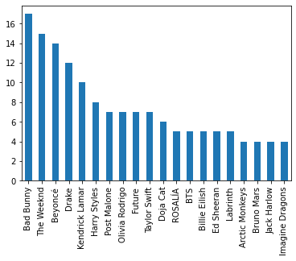

```python
spotify_frequent_artists = spotify_2022['artist_names'].value_counts()[:20].plot.bar()
```

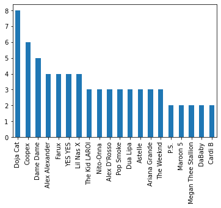

```python
tiktok_frequent_artists = tiktok_2022['artist_name'].value_counts()[:20].plot.bar()
```

##### Upon initial glance, it does not seem like our two graphs share many names. The top 20 artists with the most appearances on Spotify's top charts and TikTok as well don't appear to overlap. However lets do a quick analysis to double check

```python
spotify_artists_list = spotify_2022['artist_names'].value_counts()[:20].index.tolist()
spotify_artists_list
```

```
['Bad Bunny',
 'The Weeknd',
 'Beyoncé',
 'Drake',
 'Kendrick Lamar',
 'Harry Styles',
 'Post Malone',
 'Olivia Rodrigo',
 'Future',
 'Taylor Swift',
 'Doja Cat',
 'ROSALÍA',
 'BTS',
 'Billie Eilish',
 'Ed Sheeran',
 'Labrinth',
 'Arctic Monkeys',
 'Bruno Mars',
 'Jack Harlow',
 'Imagine Dragons']
```

```python
tiktok_artists_list = tiktok_2022['artist_name'].value_counts()[:20].index.tolist()
tiktok_artists_list
```

```
['Doja Cat',
 'Coopex',
 'Dame Dame',
 'Alex Alexander',
 'Farux',
 'YES YES',
 'Lil Nas X',
 'The Kid LAROI',
 'Nito-Onna',
 "Alex D'Rosso",
 'Pop Smoke',
 'Dua Lipa',
 'Astelle',
 'Ariana Grande',
 'The Weeknd',
 'P.S.',
 'Maroon 5',
 'Megan Thee Stallion',
 'DaBaby',
 'Cardi B']
```

```python
shared_artists = list(set(spotify_artists_list).intersection(tiktok_artists_list))
shared_artists
```

```
['The Weeknd', 'Doja Cat']
```

##### As seen by the list of shared artists above, the top 20 of TikTok and Spotify for appearances do have some overlap. Both The Weeknd and Doja Cat were popular amongst both platforms. However, lets expand our search to include artists that aren't as popular as the top 20.

##### What we're now gonna do is look at the songs with the most weekly appearances in Spotify's top chart, and see if any such songs were influenced by TikTok. As an important note, songs with > 52 value for weeks on the chart, have been on the chart since before the beginning of the year of 2022.

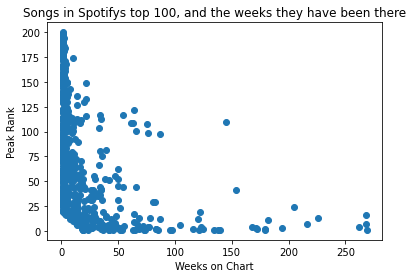

```python
plt.scatter(spotify_2022['weeks_on_chart'], spotify_2022['peak_rank'])
plt.title('Songs in Spotifys top 100, and the weeks they have been there')
plt.xlabel('Weeks on Chart')
plt.ylabel('Peak Rank')
plt.show()
```

##### Although it doesn't relate to finding TikTok's influence on Spotify's top songs, it's important to note the appearance of a correlation between the weeks a song spends on Spotify's top charts, and it's Peak Rank. Because 1 is the highest rank you can be, it can be said that the higher the peak rank of a song, the more weeks it will spend on the Spotify's top 200, and vice versa.

##### Now lets create a second plot, but this one that distinguishes between songs that appeared often on TikTok and Spotify, and those that just appeared on Spotify

```python
merged = spotify_2022.merge(tiktok_2022, on='track_name')
merged
```

|  | artist_names | track_name | peak_rank | weeks_on_chart | danceability_x | energy_x | key_x | loudness_x | mode_x | speechiness_x | ... | key_y | speechiness_y | acousticness_y | instrumentalness_y | liveness_y | valence | tempo_y | time_signature_y | duration_ms_y | rank_y |
| --- | --- | --- | --- | --- | --- | --- | --- | --- | --- | --- | --- | --- | --- | --- | --- | --- | --- | --- | --- | --- | --- |
| 0 | Imagine Dragons | Demons | 194 | 2 | 0.505 | 0.710 | 3 | -3.015 | 1 | 0.0321 | ... | 8 | 0.2170 | 0.31700 | 0.000000 | 0.3490 | 0.290 | 124.056 | 4 | 129693 | 57.432447 |
| 1 | Labrinth | Forever | 185 | 1 | 0.563 | 0.459 | 4 | -7.781 | 0 | 0.0292 | ... | 11 | 0.0817 | 0.00421 | 0.000035 | 0.0775 | 0.266 | 124.998 | 4 | 167040 | 54.945198 |
| 2 | Labrinth | Forever | 185 | 1 | 0.563 | 0.459 | 4 | -7.781 | 0 | 0.0292 | ... | 4 | 0.0427 | 0.02330 | 0.000000 | 0.1930 | 0.333 | 124.038 | 4 | 181308 | 52.161693 |
| 3 | Vance Joy | Riptide | 122 | 64 | 0.484 | 0.731 | 1 | -6.694 | 1 | 0.0379 | ... | 3 | 0.2780 | 0.05840 | 0.000001 | 0.1090 | 0.373 | 101.996 | 4 | 172431 | 53.214324 |
| 4 | OneRepublic | Counting Stars | 117 | 54 | 0.664 | 0.705 | 1 | -4.972 | 0 | 0.0382 | ... | 7 | 0.2640 | 0.50100 | 0.000000 | 0.1090 | 0.454 | 124.791 | 4 | 144935 | 54.839935 |
| ... | ... | ... | ... | ... | ... | ... | ... | ... | ... | ... | ... | ... | ... | ... | ... | ... | ... | ... | ... | ... | ... |
| 73 | Imagine Dragons, JID, Arcane, League of Legends | Enemy (with JID) - from the series Arcane Leag... | 3 | 21 | 0.728 | 0.783 | 11 | -4.424 | 0 | 0.2660 | ... | 11 | 0.2660 | 0.23700 | 0.000000 | 0.4340 | 0.555 | 77.011 | 4 | 173381 | 89.984807 |
| 74 | Jack Harlow | First Class | 2 | 18 | 0.902 | 0.582 | 5 | -5.902 | 0 | 0.1090 | ... | 8 | 0.1020 | 0.02540 | 0.000010 | 0.1130 | 0.324 | 106.998 | 4 | 173948 | 91.419425 |
| 75 | Harry Styles | As It Was | 1 | 19 | 0.520 | 0.731 | 6 | -5.338 | 0 | 0.0557 | ... | 6 | 0.0557 | 0.34200 | 0.001010 | 0.3110 | 0.662 | 173.930 | 4 | 167303 | 98.651112 |
| 76 | Harry Styles | As It Was | 1 | 19 | 0.520 | 0.731 | 6 | -5.338 | 0 | 0.0557 | ... | 9 | 0.0481 | 0.00321 | 0.000001 | 0.3970 | 0.483 | 104.980 | 4 | 124571 | 48.154097 |
| 77 | GAYLE | abcdefu | 1 | 19 | 0.695 | 0.540 | 4 | -5.692 | 1 | 0.0493 | ... | 4 | 0.0493 | 0.29900 | 0.000000 | 0.3670 | 0.415 | 121.932 | 4 | 168602 | 88.195334 |

78 rows × 35 columns

##### Let's see if we can plot them and get a better sense on the influence TikTok is having on a songs ability to make it onto the Top 200 charts.

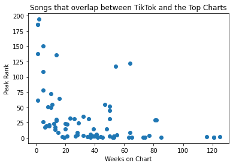

```python
plt.scatter(merged['weeks_on_chart'], merged['peak_rank'])
plt.title('Songs that overlap between TikTok and the Top Charts')
plt.xlabel('Weeks on Chart')
plt.ylabel('Peak Rank')
plt.show()
```

##### Of the songs that overlap between TikTok and Spotify's most popular, a lot of the songs cluster in the peak range of 50 and below. This indicates that a lot of songs that are also popular on TikTok are listened to often on Spotify, and thus they have high peaks. However, it's also important to notice that a lot of songs have spent a long time on the charts. Of the songs that cluster in the peak range of 50 and below, most have been on the charts in the realm of 20 to 60 weeks, with many also exceeding 60 weeks on the charts. This time period dates back to over a year ago. This could mean two things. This could mean that some songs that became big on TikTok retained their relevance and are still big, showing that TikTok has been incredibly influential in making songs popular and allowing them to stay popular for a long time. This could also mean that TikTok users are using already popular Spotify songs within their videos. Both are possible conclusions, and a little bit of both is likely true.

##### Lets now take a look at the songs that overlapped between the two services and see if any artists in particular got a boost in listens from TikTok promotion

```python
# top 10 artists of 2021 (in terms of which artists appeared the most frequently in the top 600
artists_df = pd.DataFrame(merged['artist_names'].value_counts())
artists_df.rename({'artist_names': 'Did TikTok influence artist popularity on Spotify'}, axis=1, inplace=True)
print(artists_df.iloc[:10])
```

```
                   Did TikTok influence artist popularity on Spotify
Harry Styles                                                       3
Doja Cat                                                           3
The Weeknd                                                         3
Olivia Rodrigo                                                     2
Labrinth                                                           2
Lil Nas X                                                          2
Farruko                                                            1
Ed Sheeran                                                         1
Nicky Youre, dazy                                                  1
Måneskin                                                           1
```

##### Harry Styles, Doja Cat, and The Weeknd appear to benefit the most from people using their songs on TikTok

## Drawing Conclusions

### Hypothesis Testing for 2021 Spotify and TikTok Data

```python
temp_spotify_2021 = spotify_2021
temp_spotify_2021 = temp_spotify_2021.drop(['peak_rank', 'weeks_on_chart', 'danceability', 'energy', 'key', 'loudness', 'mode', 'speechiness', 'acousticness', 'instrumentalness', 'liveness', 'tempo', 'time_signature', 'duration_ms', 'rank'], axis=1)
temp_spotify_2021.rename({'artist_names': 'artist_name'}, axis=1, inplace=True)
temp_spotify_2021
all_2021_top600 = pd.merge(temp_spotify_2021, temp_tiktok_2021, how='inner', on=['track_name'])
all_2021_top600 = all_2021_top600.drop(['artist_name_y'], axis=1)
all_2021_top600.rename({'artist_name_x': 'artist_name'}, axis=1, inplace=True)
all_2021_top600
```

|  | artist_name | track_name | rank |
| --- | --- | --- | --- |
| 0 | Pamungkas | To the Bone | 84.195489 |
| 1 | Elley Duhé | MIDDLE OF THE NIGHT | 97.894737 |
| 2 | Sub Urban, Bella Poarch | INFERNO | 77.272412 |
| 3 | Ruth B. | Dandelions | 96.905726 |
| 4 | Shouse, David Guetta | Love Tonight - David Guetta Remix Edit | 87.583574 |
| 5 | Taylor Swift | Wildest Dreams | 86.932331 |
| 6 | JIN | Yours | 72.726431 |
| 7 | Amaarae, Kali Uchis, Moliy | SAD GIRLZ LUV MONEY Remix (feat. Kali Uchis an... | 13.659919 |
| 8 | Gym Class Heroes, Adam Levine | Stereo Hearts (feat. Adam Levine) | 69.465587 |
| 9 | Conan Gray | Maniac | 88.636206 |
| 10 | Jaymes Young | Infinity | 92.528629 |
| 11 | MKTO | Classic | 70.244072 |
| 12 | blackbear | hot girl bummer | 13.366108 |
| 13 | Jamie Miller | Here's Your Perfect | 82.995951 |
| 14 | Sean Paul, Dua Lipa | No Lie | 90.403702 |
| 15 | Pink Sweat$ | At My Worst | 80.449971 |
| 16 | BØRNS | Electric Love | 88.151533 |
| 17 | Madison Beer | Reckless | 84.616541 |
| 18 | Doja Cat | Say So | 88.384037 |
| 19 | bbno$, Rich Brian | edamame (feat. Rich Brian) | 83.732794 |
| 20 | RealestK | WFM | 9.493349 |
| 21 | Dua Lipa | Levitating | 91.351070 |
| 22 | Jason Derulo | Take You Dancing | 86.552921 |
| 23 | dhruv | double take | 12.986698 |

#### Here, we found the songs that were in common for both the top 600 spotify songs and the top tik tok songs for 2021.

```python
common_600 = all_2021_top600["track_name"].tolist()
spotify_title = []
spotify_rank = []
tiktok_title = []
tiktok_rank = []
for i, row in spotify_2021.iterrows():
    if row["track_name"] in common_600:
        spotify_rank.append(row["rank"])
        spotify_title.append(row["track_name"])
for i, row in tiktok_2021.iterrows():
    if row["track_name"] in common_600:
        tiktok_rank.append(row["rank"])
        tiktok_title.append(row["track_name"])
```

```python
spotify_2021_matches = pd.DataFrame()
spotify_2021_matches['spotify title'] = spotify_title
spotify_2021_matches["spotify rank"] = spotify_rank
spotify_2021_matches = spotify_2021_matches.sort_values('spotify title')

tiktok_2021_matches = pd.DataFrame()
tiktok_2021_matches['tiktok title'] = tiktok_title
tiktok_2021_matches["tiktok rank"] = tiktok_rank
tiktok_2021_matches = tiktok_2021_matches.sort_values('tiktok title')
```

```python
music_2021_matches = pd.DataFrame()

music_2021_matches['track title'] = spotify_2021_matches["spotify title"]
music_2021_matches["spotify rank"] = spotify_2021_matches["spotify rank"]
music_2021_matches["tiktok rank"] = tiktok_2021_matches["tiktok rank"].tolist()
music_2021_matches
```

|  | track title | spotify rank | tiktok rank |
| --- | --- | --- | --- |
| 15 | At My Worst | 24.959350 | 80.449971 |
| 11 | Classic | 32.339657 | 70.244072 |
| 3 | Dandelions | 43.911472 | 96.905726 |
| 16 | Electric Love | 24.137308 | 88.151533 |
| 13 | Here's Your Perfect | 27.958446 | 82.995951 |
| 2 | INFERNO | 47.199639 | 77.272412 |
| 10 | Infinity | 34.281843 | 92.528629 |
| 21 | Levitating | 20.831075 | 91.351070 |
| 4 | Love Tonight - David Guetta Remix Edit | 43.785005 | 87.583574 |
| 1 | MIDDLE OF THE NIGHT | 48.419151 | 97.894737 |
| 9 | Maniac | 37.317073 | 88.636206 |
| 14 | No Lie | 27.289973 | 90.403702 |
| 17 | Reckless | 23.694670 | 84.616541 |
| 7 | SAD GIRLZ LUV MONEY Remix (feat. Kali Uchis an... | 39.150858 | 13.659919 |
| 18 | Say So | 23.315266 | 88.384037 |
| 8 | Stereo Hearts (feat. Adam Levine) | 39.096658 | 69.465587 |
| 22 | Take You Dancing | 19.168925 | 86.552921 |
| 0 | To the Bone | 48.663053 | 84.195489 |
| 20 | WFM | 21.969286 | 9.493349 |
| 5 | Wildest Dreams | 42.448058 | 86.932331 |
| 6 | Yours | 40.614273 | 72.726431 |
| 23 | double take | 18.075881 | 12.986698 |
| 19 | edamame (feat. Rich Brian) | 22.610659 | 83.732794 |
| 12 | hot girl bummer | 31.084011 | 13.366108 |

#### This dataframe displays the 2021 Spotify and TikTok ranks for the songs that had an overlap between both datasets. Our null hypothesis, is that there is no correlation between popular songs on Tik Tok during 2021 and popular songs on Spotify during 2021. The alternate hypothesis, is that there is a correlation between popular songs on Tik Tok and popular songs on Spotify for 2021.

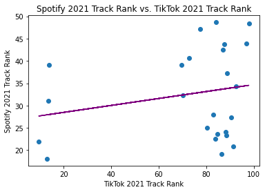

```
Regression Equation: Spotify 2021 Track Rank = 26.923425915653716 + [0.07778181] * TikTok 2021 Track Rank
                                 OLS Regression Results
=======================================================================================
Dep. Variable:                      y   R-squared (uncentered):                   0.840
Model:                            OLS   Adj. R-squared (uncentered):              0.833
Method:                 Least Squares   F-statistic:                              120.7
Date:                Fri, 16 Dec 2022   Prob (F-statistic):                    1.26e-10
Time:                        23:53:22   Log-Likelihood:                         -96.738
No. Observations:                  24   AIC:                                      195.5
Df Residuals:                      23   BIC:                                      196.7
Df Model:                           1
Covariance Type:            nonrobust
==============================================================================
                 coef    std err          t      P>|t|      [0.025      0.975]
------------------------------------------------------------------------------
x1             0.3995      0.036     10.988      0.000       0.324       0.475
==============================================================================
Omnibus:                        0.911   Durbin-Watson:                   2.341
Prob(Omnibus):                  0.634   Jarque-Bera (JB):                0.905
Skew:                           0.329   Prob(JB):                        0.636
Kurtosis:                       2.312   Cond. No.                         1.00
==============================================================================

Notes:
[1] R² is computed without centering (uncentered) since the model does not contain a constant.
[2] Standard Errors assume that the covariance matrix of the errors is correctly specified.
```

```python
spotify_2021_rank = list(map(float, music_2021_matches["spotify rank"]))
tiktok_2021_rank = list(map(float, music_2021_matches["tiktok rank"]))

plt.scatter(x = tiktok_2021_rank, y = spotify_2021_rank)
plt.title("Spotify 2021 Track Rank vs. TikTok 2021 Track Rank")
plt.ylabel("Spotify 2021 Track Rank")
plt.xlabel("TikTok 2021 Track Rank")

slope, intercept = np.polyfit(tiktok_2021_rank, spotify_2021_rank, 1)
plt.plot(tiktok_2021_rank, slope*np.array(tiktok_2021_rank) + intercept, color='Purple')
plt.show()

x = np.array(tiktok_2021_rank).reshape(-1, 1)
y = np.array(spotify_2021_rank)
reg = linear_model.LinearRegression()
reg.fit(x, y)
equation = "Regression Equation: Spotify 2021 Track Rank = {} + {} * TikTok 2021 Track Rank"
print(equation.format(reg.intercept_, reg.coef_))

model = sm.OLS(spotify_2021_rank, tiktok_2021_rank)
model = model.fit()
print(model.summary())
```

### Hypothesis Testing for 2022 Spotify and TikTok Data

```python
temp_tiktok_2022 = tiktok_2022
temp_tiktok_2022 = temp_tiktok_2022.drop(['artist_pop','album', 'track_pop','danceability','energy','loudness','mode','key','speechiness', 'acousticness', 'instrumentalness', 'liveness', 'valence', 'tempo', 'time_signature','duration_ms','rank'], axis=1)
temp_tiktok_2022
```

|  | track_name | artist_name |
| --- | --- | --- |
| 0 | Glimpse of Us | Joji |
| 1 | As It Was | Harry Styles |
| 2 | Running Up That Hill (A Deal With God) | Kate Bush |
| 3 | Late Night Talking | Harry Styles |
| 4 | Jimmy Cooks (feat. 21 Savage) | Drake |
| ... | ... | ... |
| 258 | Right Here Waiting | Boostereo |
| 259 | Looking for Love | Asketa & Natan Chaim |
| 260 | AMG | Jt5k |
| 261 | What If | HOURS |
| 262 | Fever - Remix | XY&O |

263 rows × 2 columns

```python
# Overlap with top 600 spotify songs
temp_spotify_2022 = spotify_2022
temp_spotify_2022 = temp_spotify_2022.drop(['peak_rank', 'weeks_on_chart', 'danceability', 'energy', 'key', 'loudness', 'mode', 'speechiness', 'acousticness', 'instrumentalness', 'liveness', 'tempo', 'time_signature', 'duration_ms', 'rank'], axis=1)
temp_spotify_2022.rename({'artist_names': 'artist_name'}, axis=1, inplace=True)
temp_spotify_2022
all_2022_top600 = pd.merge(temp_spotify_2022, temp_tiktok_2022, how='inner', on=['track_name'])
all_2022_top600 = all_2022_top600.drop(['artist_name_y'], axis=1)
all_2022_top600.rename({'artist_name_x': 'artist_name'}, axis=1, inplace=True)
all_2022_top600
```

|  | artist_name | track_name |
| --- | --- | --- |
| 0 | Imagine Dragons | Demons |
| 1 | Labrinth | Forever |
| 2 | Labrinth | Forever |
| 3 | Vance Joy | Riptide |
| 4 | OneRepublic | Counting Stars |
| ... | ... | ... |
| 73 | Imagine Dragons, JID, Arcane, League of Legends | Enemy (with JID) - from the series Arcane Leag... |
| 74 | Jack Harlow | First Class |
| 75 | Harry Styles | As It Was |
| 76 | Harry Styles | As It Was |
| 77 | GAYLE | abcdefu |

78 rows × 2 columns

#### Here, we found the songs that were in common for both the top 600 spotify songs and the top tik tok songs for 2022.

```python
common_600 = all_2022_top600["track_name"].tolist()
spotify_title = []
spotify_rank = []
tiktok_title = []
tiktok_rank = []
for i, row in spotify_2022.iterrows():
    if row["track_name"] in common_600:
        spotify_rank.append(row["rank"])
        spotify_title.append(row["track_name"])
for i, row in tiktok_2022.iterrows():
    if row["track_name"] in common_600 and row["track_name"] not in tiktok_title:
        tiktok_rank.append(row["rank"])
        tiktok_title.append(row["track_name"])
```

```python
spotify_2022_matches = pd.DataFrame()
spotify_2022_matches['spotify title'] = spotify_title
spotify_2022_matches["spotify rank"] = spotify_rank
spotify_2022_matches = spotify_2022_matches.sort_values('spotify title')

tiktok_2022_matches = pd.DataFrame()
tiktok_2022_matches['tiktok title'] = tiktok_title
tiktok_2022_matches["tiktok rank"] = tiktok_rank
tiktok_2022_matches = tiktok_2022_matches.sort_values('tiktok title')
```

```python
music_2022_matches = pd.DataFrame()

music_2022_matches['track title'] = spotify_2022_matches["spotify title"]
music_2022_matches["spotify rank"] = spotify_2022_matches["spotify rank"]
music_2022_matches["tiktok rank"] = tiktok_2022_matches["tiktok rank"].tolist()
music_2022_matches
```

|  | track title | spotify rank | tiktok rank |
| --- | --- | --- | --- |
| 26 | 1, 2, 3 (feat. Jason Derulo & De La Ghetto) | 44.468320 | 83.661422 |
| 70 | About Damn Time | 15.917355 | 93.887141 |
| 4 | Afraid To Feel | 103.305785 | 86.951709 |
| 48 | Ain't Shit | 28.550964 | 84.417797 |
| 19 | Another Love | 53.724518 | 90.366793 |
| ... | ... | ... | ... |
| 74 | abcdefu | 13.228650 | 88.195334 |
| 29 | drivers license | 42.319559 | 35.854585 |
| 45 | good 4 u | 30.418733 | 90.596853 |
| 56 | love nwantiti (ah ah ah) | 24.512397 | 85.622355 |
| 22 | positions | 49.592287 | 11.941400 |

75 rows × 3 columns

#### This dataframe displays the 2022 Spotify and TikTok ranks for the songs that had an overlap between both datasets. Our null hypothesis, is that there is no correlation between popular songs on Tik Tok during 2022 and popular songs on Spotify during 2022. The alternate hypothesis, is that there is a correlation between popular songs on Tik Tok and popular songs on Spotify for 2022.

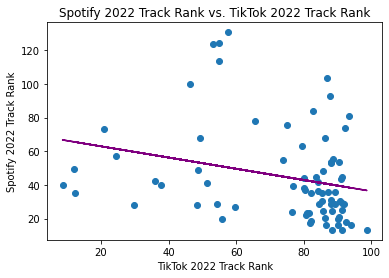

```
Regression Equation: Spotify 2022 Track Rank = 69.56533150530564 + [-0.33354831] * TikTok 2022 Track Rank
                                 OLS Regression Results
=======================================================================================
Dep. Variable:                      y   R-squared (uncentered):                   0.596
Model:                            OLS   Adj. R-squared (uncentered):              0.591
Method:                 Least Squares   F-statistic:                              109.3
Date:                Fri, 16 Dec 2022   Prob (F-statistic):                    3.17e-16
Time:                        23:53:22   Log-Likelihood:                         -370.09
No. Observations:                  75   AIC:                                      742.2
Df Residuals:                      74   BIC:                                      744.5
Df Model:                           1
Covariance Type:            nonrobust
==============================================================================
                 coef    std err          t      P>|t|      [0.025      0.975]
------------------------------------------------------------------------------
x1             0.5297      0.051     10.453      0.000       0.429       0.631
==============================================================================
Omnibus:                       14.556   Durbin-Watson:                   2.296
Prob(Omnibus):                  0.001   Jarque-Bera (JB):               16.184
Skew:                           1.091   Prob(JB):                     0.000306
Kurtosis:                       3.645   Cond. No.                         1.00
==============================================================================

Notes:
[1] R² is computed without centering (uncentered) since the model does not contain a constant.
[2] Standard Errors assume that the covariance matrix of the errors is correctly specified.
```

```python
spotify_2022_rank = list(map(float, music_2022_matches["spotify rank"]))
tiktok_2022_rank = list(map(float, music_2022_matches["tiktok rank"]))

plt.scatter(x = tiktok_2022_rank, y = spotify_2022_rank)
plt.title("Spotify 2022 Track Rank vs. TikTok 2022 Track Rank")
plt.ylabel("Spotify 2022 Track Rank")
plt.xlabel("TikTok 2022 Track Rank")

slope, intercept = np.polyfit(tiktok_2022_rank, spotify_2022_rank, 1)
plt.plot(tiktok_2022_rank, slope*np.array(tiktok_2022_rank) + intercept, color='Purple')
plt.show()

x = np.array(tiktok_2022_rank).reshape(-1, 1)
y = np.array(spotify_2022_rank)
reg = linear_model.LinearRegression()
reg.fit(x, y)
equation = "Regression Equation: Spotify 2022 Track Rank = {} + {} * TikTok 2022 Track Rank"
print(equation.format(reg.intercept_, reg.coef_))

model = sm.OLS(spotify_2022_rank, tiktok_2022_rank)
model = model.fit()
print(model.summary())
```